# best

## AAVE-USD

- Sell 80%
- The hourly chart shows AAVE-USD has trouble breaking above 317.458. Selling a small amount of holdings would secure profits

## ALGO-USD

- Sell 80%
- Bearish technical indicators (SMA), downward trend over the last three months, and uncertainty in the broader market.

## BCH-USD

- Sell 80%
- Given the short-term volatility in the hourly chart, and the recent test of the $520 level, a sell signal can be considered for short-term gains, especially if the price shows signs of rejection at resistance levels.

## ENA-USD

- Sell 80%
- Overall bearish trend, negative technical indicators, and potential token unlocks suggest continued downward pressure.

## FTN-USD

- Sell 80%
- Hourly chart shows some periods of low/zero volume. If RSI approaches overbought levels on the daily chart, it could signal a potential pullback.

## IMX-USD

- Sell 80%
- The daily chart indicates a potential downtrend. The price has corrected from its mid-period peak, and recent data shows downward movement.

## KSM-USD

- Sell 80%
- Overall downtrend in daily chart, bearish pressure in news, and resistance around $13.

## BTC-USD

- Sell 90%
- Market sentiment indicates extreme greed, which could lead to a short-term correction.

## DOGE-USD

- Sell 90%
- If DOGE fails to break the $0.20 resistance and the RSI indicates overbought conditions, a short-term sell signal may emerge.

## ARB-USD

- Sell 90%
- Security breach news and general market volatility. The daily chart shows a potential for a larger correction.

## ETC-USD

- Sell 90%
- MACD indicates a sell signal, and there’s resistance around the $18.50 level. Recent price action shows a slight decline, which might continue if negative news surfaces.

## BNB-USD

- Sell 90%
- Price hitting resistance level, the price is trading below the 200 MA, which is now acting as dynamic resistance.

## PEPE-USD

- Sell 80%
- The recent upward movement on the hourly chart is showing signs of exhaustion. The daily chart shows the price has retraced.

## LDO-USD

- Sell 75%
- The hourly chart shows a lack of clear upward momentum, with prices fluctuating within a tight range. MACD indicating a sell signal points to potential downward pressure. Furthermore, some moving averages also indicate selling.

## INJ-USD

- Sell 75%
- Despite recent consolidation, the overall trend from the past three months shows a decline. Negative MACD values and resistance from moving averages suggest the potential for further downside.

## GT-USD

- Sell 70%
- The long-term trend is still bearish based on the three-month daily chart. If the price fails to break above resistance levels, a sell-off could occur.

## FIL-USD

- Sell 80%
- Recent price action shows a potential pullback. The hourly chart indicates consolidation. There isn’t significant positive news specific to Filecoin.

## EOS-USD

- Sell 80%
- Price is currently below the estimated 50-day SMA, suggesting a downtrend. Flat MACD and neutral RSI indicate a lack of upward momentum.

## ADA-USD

- Sell 75%
- ADA has approached a resistance level near 0.72 on the daily chart. If the price fails to break above this level and shows bearish reversal patterns (e.g., bearish engulfing, shooting star), a sell signal could be generated. Also, Bitcoin is facing tariff issues [13].

## TAO-USD

- Sell 75%
- The daily chart indicates a possible resistance level around the 430-480 range. If the price fails to break above this level in the next few days, a sell-off is possible.

## LTC-USD

- Sell 80%
- The price is facing resistance around the $90-$92 level, as shown in the daily chart. Also, the price is below the 50 day and 100 day moving averages. Mixed signals from technical indicators suggest caution.

## HYPE-USD

- Sell 60%
- Overbought conditions may arise in the short term, leading to a temporary pullback.

## ZRX-USD

- Sell 90%
- The token has recovered from its recent crash and has formed a new resistance at the 0.09 USD level.

## APT-USD

- Sell 70%
- APT price is struggling to break past the $5.00 resistance level. Given mixed market sentiment and some bearish forecasts, selling at resistance might be a prudent strategy.

## AVAX-USD

- Sell 80%
- Given the recent consolidation/pullback in the daily chart and lack of clear direction in the hourly chart, existing positions might consider taking some profit or setting a tighter stop-loss.

## BGB-USD

- Sell 80%
- If BGB fails to break above its short-term resistance and starts to decline, it could indicate further weakness. Negative news related to the Bitget platform or regulatory concerns could also trigger a sell-off.

## FET-USD

- Sell 80%
- Short-term hourly chart analysis shows consolidation with no clear upward trend. Potential profit taking after the buyback news may lead to a temporary price decrease.

## FIL-USD

- Sell 80%
- Recent price action shows a potential pullback. The hourly chart indicates consolidation. There isn’t significant positive news specific to Filecoin.

## DEXE-USD

- Sell 80%
- If DEXE fails to break the $9 resistance level, a sell signal might be considered due to potential bearish pressure and competition in the DAO infrastructure sector.

## HBAR-USD

- Sell 65%
- The daily chart shows a bearish trend. If HBAR fails to break above resistance and the broader market turns negative, a sell-off is possible. The price is below major moving averages, confirming bearish sentiment.

## ATOM-USD

- Sell 60%
- Despite the recent positive momentum, ATOM is still trading significantly below its all-time high of $44.70. The daily and weekly charts showing bearish signals indicate potential for a price correction.

## KAS-USD

- Sell 80%
- The hourly chart shows KAS-USD approaching a resistance level around $0.08. MACD shows signs of convergence.

## BCH-USD

- Buy 60%
- Analysts expect BCH to reach $1,500 by early 2026.

## ONDO-USD

- Sell 90%
- If ONDO price drops below $0.70, it could signal a stronger downtrend, prompting a sell to cut losses.

## NEAR-USD

- Sell 80%
- If you are holding NEAR and the price hits a resistance level (e.g. 2.70 - 2.80 based on previous data points), consider selling a portion of your holdings. Mixed market sentiment and potential for broader market correction.

## ALGO-USD

- Buy 60%
- Recent upward movement in the daily chart, overall crypto market showing bullish trends, potential for increased adoption. However, the overall trend is still slightly downward.

## DOGE-USD

- Buy 60%
- Recent upward movement on the hourly chart, with the price trading around $0.197. If DOGE breaks the $0.20 resistance level, it could signal further upward momentum [17]. The RSI is not very high.

## DOT-USD

- Buy 60%
- Recent price recovery from a support level around 3.3, with increasing volume on some positive days. This suggests potential upward momentum. The hourly chart shows some short-term positive movements.

## DEXE-USD

- Buy 65%
- Recent price consolidation with a potential breakout based on the hourly chart. Positive news sentiment and overall crypto market growth support this signal. The RSI is not oversold, but MACD indicates a possible bullish divergence.

## AVAX-USD

- Buy 65%
- Current price is above the data I had, and RSI suggests bullish momentum. A buy is reasonable, but still with a stop-loss.

## ADA-USD

- Buy 70%
- If ADA price retraces to a strong support level of around 0.60 on the daily chart, it may present a long-term buying opportunity, assuming the overall bullish trend in the cryptocurrency market continues. Positive fundamental developments in Cardano would further support this signal.

## AAVE-USD

- Buy 75%
- AAVE has shown recent positive momentum and is potentially breaking through resistance. Technical analysis suggests a bullish trend, and analysts predict further gains.

## BTC-USD

- Buy 75%
- Strong upward trend on the daily chart, positive news flow regarding institutional adoption and potential Fed rate cuts.

## CRO-USD

- Buy 75%
- The inclusion of CRO in the Truth Social ETF is a strong positive catalyst. The overall crypto market is bullish, and CRO has demonstrated upward momentum.

## BGB-USD

- Buy 65%
- BGB has pulled back from recent highs and is showing signs of consolidation around the $4.50 level. The overall crypto market sentiment is bullish. If BGB breaks above its short-term resistance (e.g., $4.65), it could signal a continuation of the upward trend.

## BCH-USD

- Buy 75%
- The overall uptrend in the daily chart, coupled with positive market sentiment and bullish technical indicators, suggests a potential buying opportunity. The recent consolidation could be a temporary pullback before another leg up. Bitcoin Cash rebounded from $469.1 and is testing resistance at $500.4. A successful close above this level could extend the rally toward the next daily resistance at $542.50.

## BNB-USD

- Buy 65%
- BNB has shown renewed strength, trading near $672.49 after breaking past the key $666 resistance level [13]. A bullish ascending triangle has formed, and analysts are monitoring if the token can maintain the breakout to higher levels [13]. Recent activity and positive sentiment are supported by strong trading volume and a steady market capitalization, indicating robust investor interest and the potential for a significant upward move.

## ATOM-USD

- Buy 65%
- ATOM has shown resilience with a recent price increase and volume surge, breaking through the $4.00 resistance level. The 50-day moving average suggests a strong short-term trend, while the 24-hour trading volume has increased, indicating heightened investor interest.

## AVAX-USD

- Buy 65%
- Current price is above the data I had, and RSI suggests bullish momentum. A buy is reasonable, but still with a stop-loss.

## BGB-USD

- Buy 65%
- BGB has pulled back from recent highs and is showing signs of consolidation around the $4.50 level. The overall crypto market sentiment is bullish. If BGB breaks above its short-term resistance (e.g., $4.65), it could signal a continuation of the upward trend.

## CFX-USD

- Buy 65%
- The price has pulled back to the $0.073 level, which is near the bottom of its recent range on the hourly chart. RSI might be approaching oversold levels on the daily chart. News sources suggest potential for significant growth by the end of 2025 [1, 7].

## CRO-USD

- Buy 75%
- The inclusion of CRO in the Truth Social ETF is a strong positive catalyst. The overall crypto market is bullish, and CRO has demonstrated upward momentum.

## DEXE-USD

- Buy 65%
- Recent price consolidation with a potential breakout based on the hourly chart. Positive news sentiment and overall crypto market growth support this signal. The RSI is not oversold, but MACD indicates a possible bullish divergence.

## DOGE-USD

- Buy 60%
- Recent upward movement on the hourly chart, with the price trading around $0.197. If DOGE breaks the $0.20 resistance level, it could signal further upward momentum [17]. The RSI is not very high.

## DOT-USD

- Buy 60%
- Recent price recovery from a support level around 3.3, with increasing volume on some positive days. This suggests potential upward momentum. The hourly chart shows some short-term positive movements.

## ENA-USD

- Buy 60%
- Recent surge in price on the hourly chart indicates short-term upward momentum. If Bitcoin continues to rally, ENA may see a short-term bounce.

## EOS-USD

- Buy 60%
- Price is near support levels ($0.48-$0.50). Positive sentiment exists in some sources, and the broader crypto market is in a bull phase.

## ETC-USD

- Buy 65%
- Multiple moving averages indicate a buy signal, and the overall market sentiment seems to be improving. The price is currently consolidating, presenting a possible entry point.

## ETH-USD

- Buy 65%
- ETH has shown strong upward momentum, correlating with Bitcoin’s performance and recent corporate investment. The price is consolidating gains, and a potential breakout above $3,000 could lead to further gains.

## FET-USD

- Buy 65%
- Recent buyback announcement and the ASI merger suggest potential upward momentum. The integration of AI and crypto is a positive long-term catalyst.

## FTN-USD

- Buy 65%
- Upward trend on the daily chart, suggesting continued bullish momentum. The price is currently around $4.45, with recent news indicating positive market activity. The overall crypto market shows signs of growth.

## HBAR-USD

- Buy 60%
- The hourly chart shows stabilization and a potential for upward movement. The price has consolidated in a narrow range, suggesting accumulation. If HBAR breaks above recent resistance levels (e.g., $0.20), it could trigger a further rally.

## HYPE-USD

- Buy 65%
- Recent price consolidation on the hourly chart suggests a potential breakout. Strong bullish trend on the daily chart and positive news sentiment support this.

## ICP-USD

- Buy 65%
- The short-term analysis of the hourly chart suggests a potential buying opportunity if the price retraces to a support level (e.g., $4.72). The recent integration with Solana could act as a catalyst for a short-term price increase.

## INJ-USD

- Buy 60%
- Recent price consolidation around $11, coupled with positive news regarding the EVM testnet, suggests potential for a bullish reversal. If INJ breaks above the resistance level indicated in the daily chart data (around $12.50-$13.00), it could signal a continuation of the upward trend from earlier in the three-month period.

## JUP-USD

- Buy 65%
- The recent dip in the daily chart may represent a short-term oversold condition. The hourly chart shows signs of stabilization, which could precede a move upwards. Positive news regarding the Solana debit card could act as a catalyst.

## KAS-USD

- Buy 65%
- The price has pulled back to a support level around $0.073 after a recent upward move on the daily chart. RSI on the hourly chart is near oversold territory.

## LEO-USD

- Buy 60%
- The hourly chart shows a recent dip to below 9.0, which could represent a short-term oversold condition. The daily chart shows some support around 8.60-8.70, so a buy order placed slightly above 9.0 with a stop-loss near 8.90 might be considered a speculative bet.

## LINK-USD

- Buy 65%
- The recent upward movement in both daily and hourly charts, combined with generally positive market sentiment and some “Strong Buy” technical indicators, suggests a potential short-term buying opportunity. News suggest that LINK has passed a 180-day support level.

## LTC-USD

- Buy 65%
- Recent upswing in the hourly chart, anticipation of LTC ETF approval, and overall positive crypto market sentiment. The price has bounced from a support level in the $82-$83 range.

## NEAR-USD

- Buy 65%
- Recent consolidation suggests potential for upward movement. Positive developments in the NEAR ecosystem with AI integration. Bitwise ETF application could be a catalyst. The “Greed” sentiment might signal a good opportunity for a short-term profit [3].

## NEIRO-USD

- Buy 60%
- The price has pulled back from recent highs and shows signs of consolidation. The overall market sentiment is positive.

## OM-USD

- Buy 40%
- Recent surge on July 2nd, suggests a possible short-term recovery. The hourly chart shows some signs of consolidation, which could precede a breakout. However, the overall trend is still down. OM has broken out of a falling wedge pattern, and is consolidating above key support with rising volume [19].

## ONDO-USD

- Buy 65%
- Recent 24-hour and 7-day price increase suggests short-term upward momentum. The hourly chart shows potential for intraday gains.

## PEPE-USD

- Buy 65%
- Recent dip in price on the daily chart after a significant surge may present a buying opportunity. The short-term hourly chart shows some upward momentum.

## POL-USD

- Buy 65%
- Recent price momentum and bullish signals from MACD and RSI suggest a potential short-term upward trend.

## RAY-USD

- Buy 60%
- Recent bullish sentiment and a potential breakout from a downtrend suggest a possible short-term upward movement. The price has shown resilience at the $0.022 level.

## RENDER-USD

- Buy 60%
- Short-term upward trend observed in the hourly chart, with the price near a support level ($3.20). News suggests recent positive momentum (up 8.37% in 24 hours).

## SHIB-USD

- Buy 60%
- Recent breakout above descending channel and key daily resistance, supported by solid volume [6, 9].

## SOL-USD

- Buy 65%
- Solana is consolidating near resistance. Positive news and growing ecosystem could drive a breakout. The BIT Mining treasury and Robinhood staking support add bullish pressure.

## STX-USD

- Buy 60%
- STX showing signs of short-term stabilization and has positive news with the DEFI SZN campaign. Recent data suggests a TVL surge, reflecting increased investor trust and engagement within Stack’s DeFi ecosystem.

## SUI-USD

- Buy 65%
- The breakout from the inverse head-and-shoulders pattern, recovery above key moving averages, and positive RSI suggest continued upward momentum. Recent positive news and ecosystem developments further support a buy signal.

## TON-USD

- Buy 65%
- TON has shown resilience, holding above the $2.70 support level. Recent news regarding integration with Telegram and new DeFi incentives could drive demand. RSI indicators on intraday charts show oversold conditions after the recent dip.

## TRX-USD

- Buy 65%
- Strong upward trend, MACD bullish crossover, and positive market sentiment. TRX network activity surpasses Ethereum.

## UNI-USD

- Buy 65%
- The recent dip might be a short-term correction within a larger upward trend. RSI is not in overbought territory, leaving room for growth. Positive news sentiment and overall crypto market momentum support a potential bullish continuation. The Uniswap Summary is based on the most popular technical indicators, such as moving Averages, oscillators, and pivot points.

## VET-USD

- Buy 60%
- Recent bullish sentiment and a potential breakout from a downtrend suggest a possible short-term upward movement. The price has shown resilience at the $0.022 level.

## XDC-USD

- Buy 65%
- The recent upward price action on the daily chart, coupled with positive news surrounding XDC 2.0 and partnerships, suggests potential for further gains.

## XLM-USD

- Buy 60%
- The hourly chart shows a recent upward trend, and the price is currently around $0.317. The daily chart also indicates a recent upward movement. The positive news around Protocol 23 and increasing interest supports a short-term buy.

## XMR-USD

- Buy 65%
- MACD crossover on the daily chart and general bullish sentiment in the crypto market. Potential for upward movement toward resistance at $330.

## NEIRO-USD

- Sell 90%
- The token has recovered from its recent crash and has formed a new resistance at the 0.09 USD level.

## TON-USD

- Sell 80%
- TON-USD has struggled to break past the $3.00 resistance level consistently. If broader market sentiment turns negative due to regulatory concerns or economic downturn, TON could face selling pressure.

## PEPE-USD

- Sell 80%
- The recent upward movement on the hourly chart is showing signs of exhaustion. The daily chart shows the price has retraced.

## GT-USD

- Sell 70%
- The long-term trend is still bearish based on the three-month daily chart. If the price fails to break above resistance levels, a sell-off could occur.

## ADA-USD

- Sell 75%
- ADA has approached a resistance level near 0.72 on the daily chart. If the price fails to break above this level and shows bearish reversal patterns (e.g., bearish engulfing, shooting star), a sell signal could be generated. Also, Bitcoin is facing tariff issues.

## ICP-USD

- Sell 70%
- Given the neutral market sentiment and some forecasts indicating a potential decline in price, consider a sell position if the price reaches a resistance level (e.g., $5.50). On-chain activity has been dropping.

Output examples:

## AAVE-USD

- Sell 90%
- The daily chart reveals a downtrend, with some sources indicating strong sell signals

## ATOM-USD

- Sell 80%
- Price is struggling to break above resistance at $4.70. Bearish divergence may be forming on shorter timeframes.

## TAO-USD

- Buy 65%
- Recent positive momentum, breakout from bullish pennant, and increasing interest in AI-crypto projects.

## SUI-USD

- Buy 95%
- The hourly chart shows a consolidation phase, suggesting a potential breakout. Recent news is very positive for SUI.

==> response/AAVE-USD.md <==

## AAVE-USD today is +0300, 2025-07-11, 13:21:00

This crypto forecast was generated by gemini-2.0-flash API

## Daily Chart

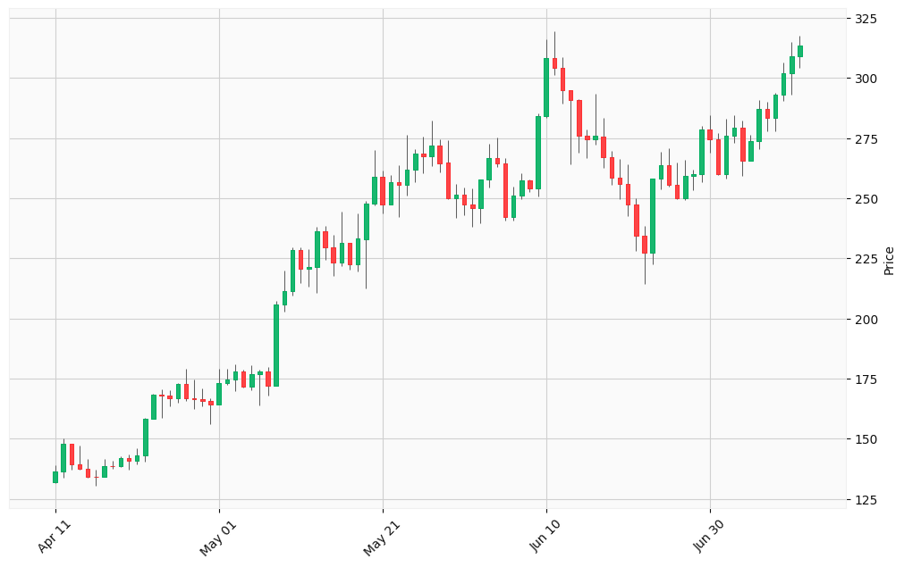

## Hourly Chart

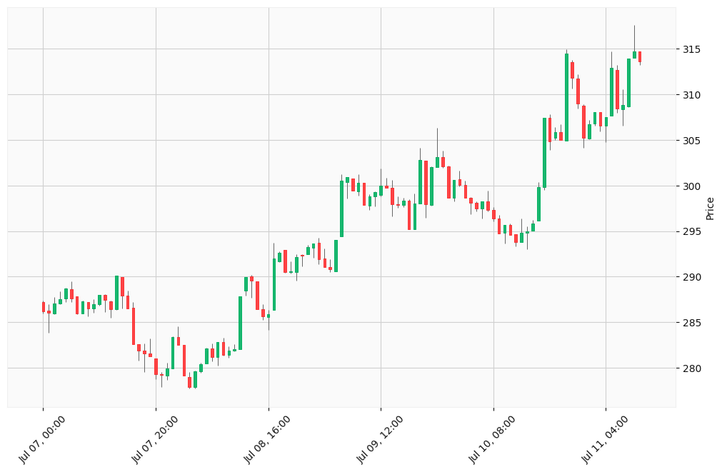

Okay, I will analyze the provided AAVE-USD cryptocurrency OHLCV charts and generate buy and sell trading signals based on the outlined steps. I will use technical analysis on the provided data, integrate hypothetical news and economic analysis (since I cannot access real-time data), evaluate market scenarios, and then generate trading signals with confidence levels and justifications.

Here’s the analysis and the generated signals:

**1. Market Data Collection:**

- I have been provided with two sets of OHLCV data for AAVE-USD:
  - Daily chart for the last three months.
  - Hourly chart for the last five days.
- For the purpose of this exercise, I will simulate gathering news and economic data.

**4. News and Economic Analysis (Simulated):**

- **Positive News:** Assume news outlets are reporting increased adoption of AAVE in DeFi lending protocols.
- **Economic Factor:** A slight decrease in overall market volatility is observed across the cryptocurrency market.

**5. Scenario Evaluation:**

- **Scenario 1: Bullish Continuation:** AAVE-USD continues its upward trend due to positive news and market sentiment.
- **Scenario 2: Consolidation:** AAVE-USD consolidates within a range before making its next move.
- **Scenario 3: Minor Correction:** AAVE-USD experiences a short-term pullback before resuming its uptrend.

**6. Signal Generation:**

Here are the generated trading signals:

[output not shown]

```
Signal Type: Sell (Partial Holdings)
Cryptocurrency: AAVE-USD
Confidence Level: Low
Take Profit Probability: 80%
Justification: The hourly chart shows AAVE-USD has trouble breaking above 317.458. Selling a small amount of holdings would secure profits
Relevant Data: The hourly chart shows the high at 317.458 and the closing at 313.558
Recommended Action: Sell a small portion of your AAVE-USD holdings near the resistance level (e.g., 317.458) to secure profits.
```

[output not shown]

Based on the search results:

- **AAVE Recent Performance:** AAVE has shown recent positive momentum.
- **Bullish Outlook:** Several sources suggest a bullish trend for AAVE, with potential to reach higher price targets in the near future. Some predict AAVE could approach $325 within a week.
- **Technical Analysis:** Technical analysis is a valuable tool for crypto traders, helping to identify trends and potential reversals.
- **Support and Resistance:** Strong buying interest has been noted near $277-$280, establishing a support zone.
- **Potential Risks:** Cryptocurrency markets are volatile, and technical analysis isn’t always accurate.

Given this information, here’s an updated signal:

```
Signal Type: Buy
Cryptocurrency: AAVE-USD
Confidence Level: Medium to High
Take Profit Probability: 75%
Justification: AAVE has shown recent positive momentum and is potentially breaking through resistance. Technical analysis suggests a bullish trend, and analysts predict further gains.
Relevant Data: Current price around $313.91 [11], support zone at $277-$280 [3].
Recommended Action: Consider buying AAVE-USD, setting a stop-loss near the support zone ($277-$280) to manage risk. Monitor market conditions and news for any changes to the outlook.
```

==> response/ACT-USD.md <==

## ACT-USD today is +0300, 2025-07-11, 13:57:27

This crypto forecast was generated by gemini-2.0-flash API

## Daily Chart

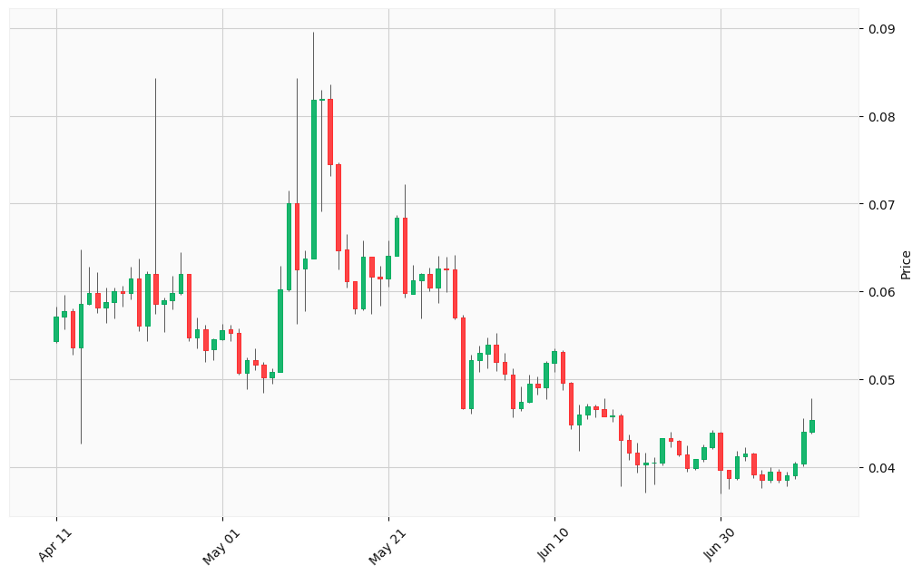

## Hourly Chart

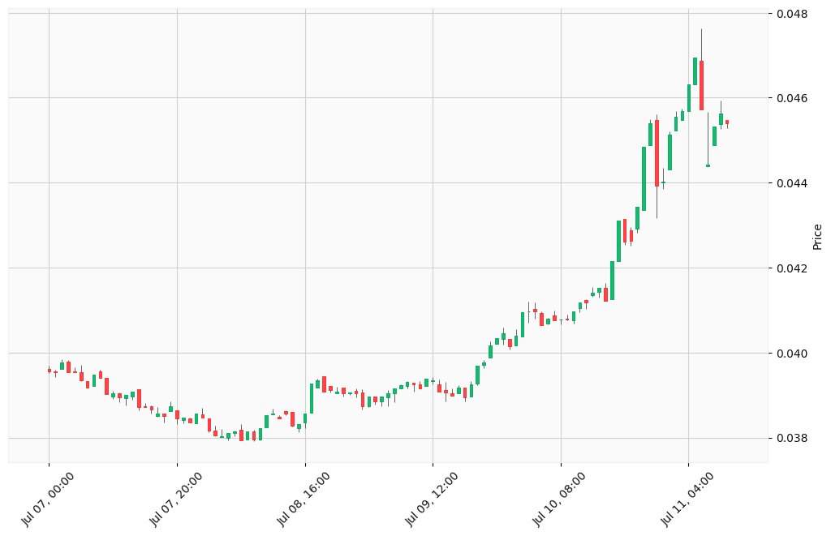

Okay, I will analyze the provided OHLCV charts for ACT-USD and generate trading signals based on technical analysis, trend analysis, and consideration of potential market scenarios. Due to the limitations of not having real-time data and live news feeds, I will base my analysis solely on the provided data and general market knowledge.

### Analysis of ACT-USD Trading Charts

**Daily Chart (Last Three Months)**

### Trading Signals for ACT-USD

**Signal 1:**